# Data 605 - Assignment 14

Leticia Salazar

5/6/2022

$~$

### Taylor Series Approximations

#### This week, we’ll work out some Taylor Series expansions of popular functions

#### (1) $f(x) = \frac{1}{(1 - x)}$

#### (2) $f(x) = e^x$

#### (3) $f(x) = ln(1 + x)$

#### (4) $f(x) = x^{(\frac{1}{2})}$

#### For each function, only consider its valid ranges as indicated in the notes when you are computing the Taylor Series expansion. Please submit your assignment as an R- Markdown document.

$~$

### Manual work:

#### Equation 1:

$f(x)=\frac{1}{(1 - x)}$

$f(a)=\frac{1}{1 - a}$ : $f(0) = 1$

$f'(a)=\frac{1}{(1 - a)^2}$ : $f^{(1)}(0) = 1$

$f''(a)=\frac{2}{(1 - a)^3}$ : $f^{(2)}(0) = 2$

$f'''(a)=\frac{6}{(1 - a)^4}$ : $f^{(3)}(0) = 6$

$f^{(4)}(a)=\frac{24}{(1 - a)^5}$ : $f^{(4)}(0) = 24$

$= f(a)+f'(a)(x-a)+\frac{f''(a)}{2!}(x-a)^2+\frac{f'''(a)}{3!}(x-a)^3+...$

generalized as: $f^{(n)}(x) = \frac{n!}{(1-x)^{n+1}}$

substituting the general equation: $\frac{1}{1-x} \approx \sum_{n=0}^{\infty}\frac{n!}{(1-a)^{n+1}}\times \frac{(x-a)^n}{n!} = \frac{(x-a)^n}{(1-a)^n}$

when a = 0 it becomes: $\frac{1}{1-x} \approx \sum_{n=0}^{\infty}x^n$

$~$

#### Equation 2:

$f(x) = e^x$

The derivative of $f(x) = e^x$ is $e^x$ and any derivative of $f^{(n)}(x)=e^x$

$~$

#### Equation 3:

$f(x) = ln(1+x)$

$f(x) = ln(x)$

$f^{(1)}(x) = \frac{1}{1+x}$

$f^{(2)}(x) = \frac{-1}{(1+x)^2}$

$f^{(3)}(x) = \frac{2}{(1+x)^3}$

$f^{(4)}(x) = \frac{-6}{(1+x)^4}$

generalized as: $f^{(n)}(x) = (-1)^{n-1}\frac{(n-1)!}{(1+x)^n}$

substitute to the general equation: $ln(1 + x) \approx \sum_{n = 0}^{\infty} (-1)^{n - 1} \frac{(n - 1)!}{(1 + a)^n}\times\frac{(x - a)^a}{n!} = (-1)^{n - 1}\frac{(x - a)^n}{n(1 + a)^n}$

when a = 0 it becomes: $ln(1+x) \approx \sum_{n=0}^{\infty}(-1)^{n-1}\frac{x^n} {n}$

$~$

#### Equation 4:

$f(x) = x^{(\frac{1}{2})}$

##### I was unsure how to approach this problem so I searched up help and this is how it was approached:

defined as: $f(x) = f(a) + \frac{f'(a)}{1!}(x - a) + \frac{f''(a)}{2!}(x - a)^2 + \frac{f''"(a)}{3!}(x - a)^3 + ...$

derivatives: $= 1 + \frac{\frac{1}{2}}{1!}(x - 1) + \frac{-\frac{1}{4}}{2!}(x - 1)^2 + \frac{\frac{3}{8}}{3!}(x - 1)^3 + \frac{-\frac{15}{16}}{4!}(x - 1)^4$

refine: $= 1 + \frac{1}{2}(x - 1) - \frac{1}{8}(x - 1)^2 + \frac{1}{16}(x - 1)^3 - \frac{5}{128}(x - 1)^4 + ...$

$~$

### Using the pracma library for Taylor Series:

```r
library(pracma)
library(expm)
```

```r
# Equation 1
f <- function(x) (1/(1-x))
p <- taylor(f, 0, 5)
p
```

```
## [1] 1.000293 1.000029 1.000003 1.000000 1.000000 1.000000
```

```r
sum(p)
```

```
## [1] 6.000325
```

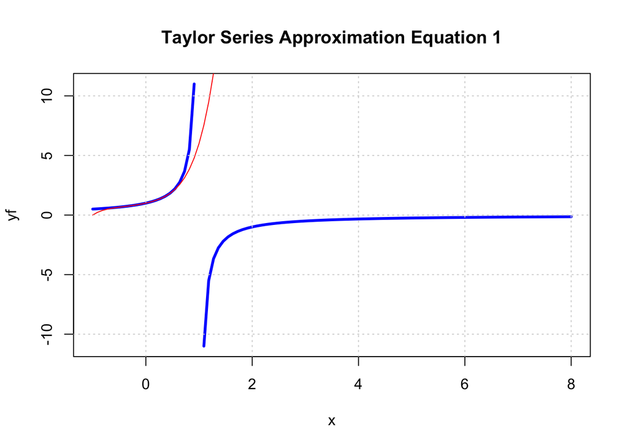

```r
x <- seq(-1, 8, length.out = 100)
yf <- f(x)
yp <- polyval(p, x)
plot(x, yf, type = "l", main = "Taylor Series Approximation Equation 1", col = "blue", lwd = 3)
lines(x, yp, col = "red")
grid()
```

```r
# Equation 2
f_2 <- function(x) exp(x)
p_2 <- taylor(f_2, 0, 5)
p_2
```

```
## [1] 0.008334245 0.041666573 0.166666726 0.499999996 1.000000000 1.000000000
```

```r
sum(p_2)
```

```
## [1] 2.716668
```

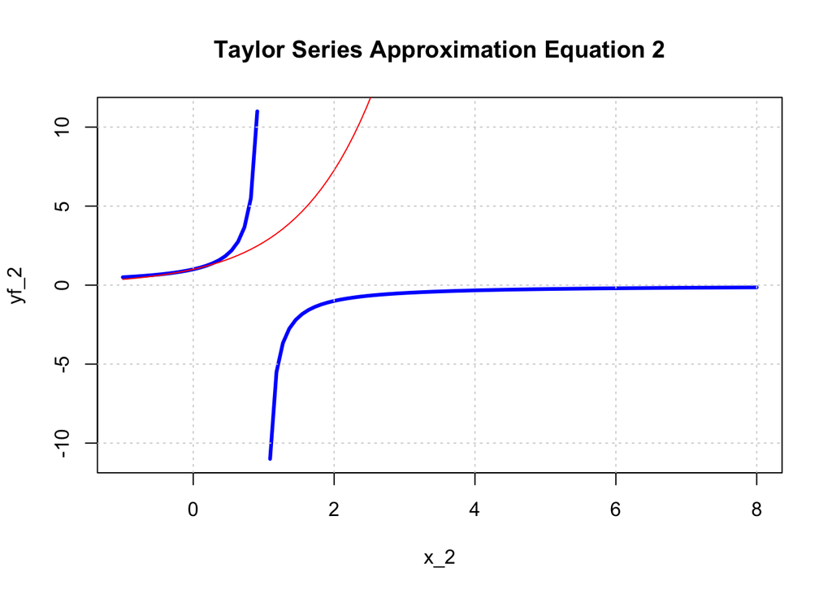

```r
x_2 <- seq(-1, 8, length.out = 100)
yf_2 <- f(x_2)
yp_2 <- polyval(p_2, x_2)
plot(x_2, yf_2, type = "l", main = "Taylor Series Approximation Equation 2", col = "blue", lwd = 3)
lines(x_2, yp_2, col = "red")
grid()
```

```r
# Equation 3
f_3 <- function(x) (log(1 + x))
p_3 <- taylor(f_3, 0, 5)
p_3
```

```
## [1]  0.2000413 -0.2500044  0.3333339 -0.5000000  1.0000000  0.0000000
```

```r
sum(p_3)
```

```
## [1] 0.7833707
```

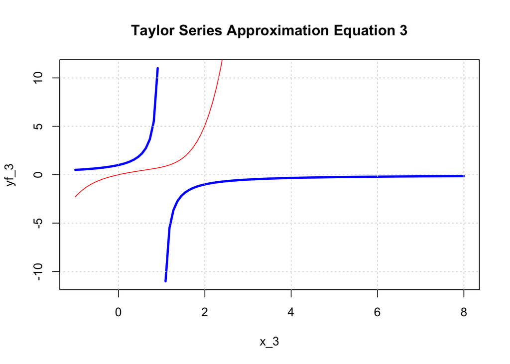

```r
x_3 <- seq(-1, 8, length.out = 100)
yf_3 <- f(x_3)
yp_3 <- polyval(p_3, x_3)
plot(x_3, yf_3, type = "l", main = "Taylor Series Approximation Equation 3", col = "blue", lwd = 3)
lines(x_3, yp_3, col = "red")
grid()
```

```r
# Equation 4
f_4 <- function(x) {ifelse(x == 0, (1/2), f(x))}
p_4 <- taylor(f_4, x0 = 0, n = 5)
p_4
```

```
## [1]  1.000293e+00 -3.408918e+09  1.000003e+00  3.355443e+07  1.000000e+00
## [6]  5.000000e-01
```

```r
sum(p_4)
```

```
## [1] -3375363364
```

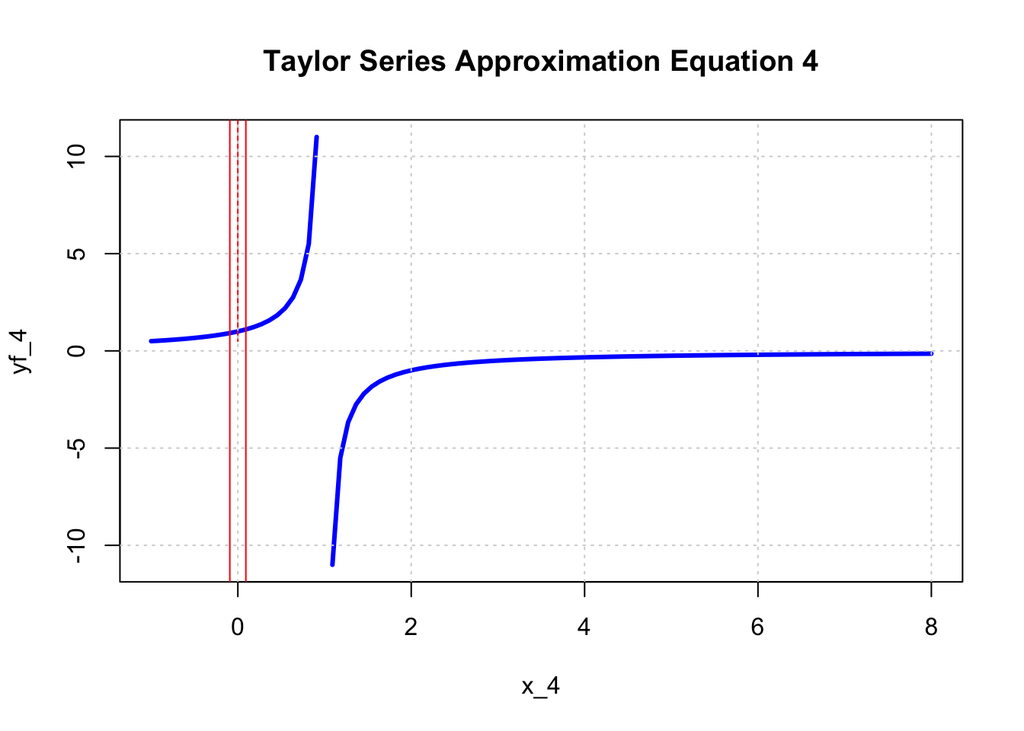

```r
x_4 <- seq(-1, 8, length.out = 100)
yf_4 <- f(x_4)
yp_4 <- polyval(p_4, x_4)
plot(x_4, yf_4, type = "l", main = "Taylor Series Approximation Equation 4", col = "blue", lwd = 3)
lines(x_4, yp_4, col = "red")
grid()
```

### Thoughts:

Do equation 4 make sense? Is there something I am missing or not doing correctly?

### References:

https://www.mathsisfun.com/algebra/taylor-series.html

https://www.symbolab.com/solver/first-derivative-calculator/taylor%20x%5E%7B%5Cfrac%7B1%7D%7B2%7D%7D?or=input

https://stackoverflow.com/questions/58495044/how-can-i-find-taylor-series-of-sqrt1x-1x/58495272#58495272